# Mapping Gorontalo Province with R

Irvan Nani

2026-10-25

# 1 Introduction

Welcome to our tutorial on mapping Gorontalo Province using R!

In this tutorial, we will create an administrative map of Gorontalo Province, Indonesia, showing its five regencies and one city.

We will work with spatial data, explore administrative boundaries, customise map colours, add geographic labels, and export our final map in high-resolution formats.

By the end of this tutorial, we will have created a map suitable for academic research and learned how to reproduce a similar map for other regions.

## 1.1 What will we learn?

Throughout this tutorial, we will learn how to:

1. Retrieve administrative boundary data.
2. Explore and manipulate spatial datasets.
3. Extract Gorontalo’s administrative divisions.
4. Create maps using `ggplot2`.
5. Add labels and customise map aesthetics.
6. Export maps as PNG and PDF files.

# 2 Preparing Our R Environment

Before we begin mapping, let’s prepare our R environment by loading the required packages.

## 2.1 Let’s load our packages!

We will use four R packages for spatial data processing, manipulation, visualisation, and labelling.

```r
# Let's load our packages!
library(sf)       # Spatial data
library(dplyr)    # Data manipulation
```

```r
library(ggplot2)  # Map visualisation
library(ggrepel)  # Map labels
```

## 2.2 Understanding our packages

Each package serves a different purpose:

| Package | Purpose |
| --- | --- |
| `sf` | Reading, processing, and managing spatial data |
| `dplyr` | Filtering, selecting, and transforming data |
| `ggplot2` | Creating and customising maps |
| `ggrepel` | Positioning labels while reducing overlaps |

Note that our mapping workflow is implemented in R (R Core Team, 2026) and supported by several open-source packages. The `sf` package provides tools for reading, processing, and managing spatial vector data (Pebesma, 2018; Pebesma & Bivand, 2023). The `dplyr` package supports data manipulation and transformation (Wickham et al., 2026), while `ggplot2` provides a flexible framework for constructing and customising geographic visualisations (Wickham, 2016). Finally, `ggrepel` helps position geographic labels while reducing unwanted text overlaps (Slowikowski, 2026).

Together, these packages provide the tools needed to create a reproducible administrative map of Gorontalo Province.

## 2.3 A quick note before we kick off

**Note**

If you have already installed these packages, you only need to load them using `library()`. You do not need to reinstall them every time you open RStudio.

## 2.4 What have we learned?

We have prepared our R environment and identified the packages required for mapping.

We are now ready to retrieve the spatial data for Gorontalo Province!

# 3 Retrieving Provincial Boundary of Gorontalo

Now that our R environment is ready, let’s retrieve the geographic data needed to create our map!

Before exploring Gorontalo’s five regencies and one city, we first need to obtain the provincial boundary.

We will use administrative boundary data from `wilayah-id`, which provides geographic features for Indonesia.

## 3.1 Let’s retrieve Indonesian provincial boundaries!

Before constructing our map, we first need to retrieve administrative boundary data for Indonesia.

In this tutorial, we use the wilayah-id API, developed by Dhany Yudi Prasetyo, to access Indonesian administrative geographic information (Prasetyo, 2026).

According to the project’s documentation, the underlying administrative boundary geometries originate from Badan Informasi Geospasial (BIG), while administrative codes and regional names are based on information from the Ministry of Home Affairs of the Republic of Indonesia (Kemendagri) (Prasetyo, 2026).

The API provides geographic features in GeoJSON format, which can be read directly into R using the sf package (Pebesma, 2018).

Now let’s construct our data URL and retrieve the provincial boundaries!

```r
# Let's retrieve the provincial boundaries!
url_provinces <- paste0(
  "https://wilayah-id-api.dhanypedia.com",
  "/api/v1/ogc/features/collections/provinces/items",
  "?limit=100&f=geojson"
)

Indonesian_map_level1 <- sf::st_read(
  url_provinces,
  quiet = TRUE
)

# Let's inspect our dataset!
names(Indonesian_map_level1)
```

```
##  [1] "id"              "kode_prov"       "nama_provinsi"   "area_km2"
##  [5] "jumlah_penduduk" "jumlah_kk"       "kepadatan"       "luas_wilayah"
##  [9] "jumlah_kab"      "jumlah_kota"     "jumlah_kec"      "jumlah_desa"
## [13] "jumlah_kel"      "geometry"
```

```r
nrow(Indonesian_map_level1)
```

```
## [1] 38
```

**Understanding our code**

Let’s explore the functions we have just used!

| Function | What does it do? |
| --- | --- |
| `paste0()` | Combines text strings to construct our data URL |
| `st_read()` | Reads geographic data into R |
| `quiet = TRUE` | Suppresses routine data-loading messages |
| `names()` | Displays the variable names in our dataset |
| `nrow()` | Counts the number of observations |

The URL requests geographic features in GeoJSON format, which can be read directly using the `sf` package.

**What should we expect?**

The dataset should contain 38 provincial features, representing Indonesia’s 38 provinces.

## 3.2 Let’s extract Gorontalo Province!

Now that we have retrieved the provincial boundaries, let’s focus on Gorontalo.

We can use `filter()` from the `dplyr` package to select the province we need.

```r
# Let's extract Gorontalo Province!
gorontalo_province <- Indonesian_map_level1 %>%
  filter(nama_provinsi == "Gorontalo")

# Let's inspect our result!
print(gorontalo_province)
```

```
## Simple feature collection with 1 feature and 13 fields
## Geometry type: MULTIPOLYGON
## Dimension:     XY
## Bounding box:  xmin: 121.1612 ymin: 0.306254 xmax: 123.5523 ymax: 1.055408
## Geodetic CRS:  WGS 84
##   id kode_prov nama_provinsi   area_km2 jumlah_penduduk jumlah_kk kepadatan
## 1 75        75     Gorontalo 12024.3668         1250960    407136      <NA>
##   luas_wilayah jumlah_kab jumlah_kota jumlah_kec jumlah_desa jumlah_kel
## 1      12025.0          5           1         77         657         72
##                         geometry
## 1 MULTIPOLYGON (((121.3378 0....
```

```r
# Let's count our selected provinces!
nrow(gorontalo_province)
```

```
## [1] 1
```

**Understanding our code**

The pipe operator `%>%` passes the dataset to the next function.

The `filter()` function selects observations that satisfy a particular condition.

Here, we use:

`nama_provinsi == "Gorontalo"`

This tells R to select only the observation whose province name is Gorontalo.

**What should we expect?**

The final command should return:

```
[1] 1
```

This confirms that we have successfully extracted one provincial feature.

## 3.3 Let’s take a quick look at our provincial boundary!

Before moving on to the regencies and city, let’s visualise the provincial boundary.

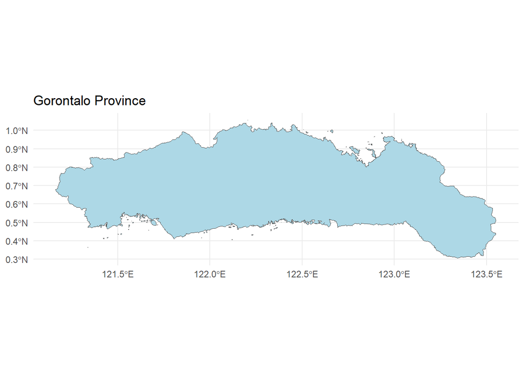

```r
# Let's preview Gorontalo Province!
ggplot() +
  geom_sf(
    data = gorontalo_province,
    fill = "lightblue",
    color = "grey30"
  ) +
  labs(
    title = "Gorontalo Province"
  ) +
  theme_minimal()
```

**Understanding our code**

- `ggplot()` initialises our visualisation.
- `geom_sf()` draws the geographic boundary.
- `fill` determines the colour inside the province.
- `color` determines the boundary colour.
- `labs()` adds a map title.
- `theme_minimal()` provides a clean visual appearance.

At this stage, we are only visualising the provincial boundary. The internal boundaries of the five regencies and one city will be added in the next steps.

## 3.4 What have we learned?

In this step, we have learned how to:

1. Retrieve geographic data from an online source.
2. Import GeoJSON data using `sf`.
3. Inspect the structure of a spatial dataset.
4. Extract a specific province using `dplyr`.
5. Visualise a provincial boundary using `ggplot2`.

We now have our first spatial object, `gorontalo_province`, which will serve as the foundation for our administrative map.

Next, let’s retrieve Gorontalo’s five regencies and one city!

# 4 Retrieving Administrative Divisions of Gorontalo Province

Now that we have obtained Gorontalo’s provincial boundary, let’s explore its administrative divisions!

Gorontalo Province consists of five regencies (*kabupaten*) and one city (*kota*). To map these divisions, we need a more detailed spatial dataset containing regency and city boundaries.

## 4.1 Let’s retrieve Indonesian regency and city boundaries!

We will use the same data source as before, but this time we will retrieve administrative boundaries at the regency and city level.

```r
# Let's retrieve the regency and city boundaries!
url_regencies <- paste0(
  "https://wilayah-id-api.dhanypedia.com",
  "/api/v1/ogc/features/collections/regencies/items",
  "?limit=1000&f=geojson"
)

Indonesian_map_level2 <- sf::st_read(
  url_regencies,
  quiet = TRUE
)

# Let's inspect our dataset!
names(Indonesian_map_level2)
```

```
##  [1] "id"              "kode_kab"        "kode_prov"       "nama_kabupaten"
##  [5] "tipe"            "area_km2"        "jumlah_penduduk" "jumlah_kk"
##  [9] "kepadatan"       "luas_wilayah"    "jumlah_kec"      "jumlah_desa"
## [13] "jumlah_kel"      "geometry"
```

```r
# Let's inspect the first six records!
head(sf::st_drop_geometry(Indonesian_map_level2))
```

|  | id | kode_kab | kode_prov | nama_kabupaten | tipe | area_km2 | jumlah_penduduk | jumlah_kk | kepadatan | luas_wilayah | jumlah_kec | jumlah_desa | jumlah_kel |
| --- | --- | --- | --- | --- | --- | --- | --- | --- | --- | --- | --- | --- | --- |
| 1 | 1101 | 1101 | 11 | Kabupaten Aceh Selatan | KABUPATEN | 4174.2192 | 238021 | 72026 | 57.00589767 | 4175.375 | 18 | 260 | 0 |
| 2 | 1102 | 1102 | 11 | Kabupaten Aceh Tenggara | KABUPATEN | 4179.0299 | 233627 | 68306 | 55.9033558 | 4179.123 | 16 | 385 | 0 |
| 3 | 1103 | 1103 | 11 | Kabupaten Aceh Timur | KABUPATEN | 5409.0928 | 454723 | 132195 | 84.06154020999999 | 5409.406 | 24 | 513 | 0 |
| 4 | 1104 | 1104 | 11 | Kabupaten Aceh Tengah | KABUPATEN | 4468.4205 | 230771 | 70149 | 51.64491139 | 4468.417 | 14 | 295 | 0 |
| 5 | 1105 | 1105 | 11 | Kabupaten Aceh Barat | KABUPATEN | 2782.3686 | 207690 | 66150 | 74.63150492 | 2782.873 | 12 | 322 | 0 |
| 6 | 1106 | 1106 | 11 | Kabupaten Aceh Besar | KABUPATEN | 2890.7152 | 439048 | 130573 | 151.84212083 | 2891.477 | 23 | 604 | 0 |

**Understanding our code**

We use the same functions introduced in Step 2, but there are two important differences.

First, our URL now contains `regencies` instead of `provinces`. This allows us to retrieve administrative boundaries at a more detailed level.

Second, we use `st_drop_geometry()` to inspect the attribute data without displaying the geographic shapes.

| Function | What does it do? |
| --- | --- |
| `paste0()` | Constructs the URL for our spatial dataset |
| `st_read()` | Imports the geographic features into R |
| `names()` | Displays the available variables |
| `st_drop_geometry()` | Removes the geometry column from a displayed dataset |
| `head()` | Displays the first six observations |

**What should we expect?**

Our dataset should contain several variables describing Indonesia’s regencies and cities, including their administrative codes, names, and geographic boundaries.

## 4.2 Let’s explore our administrative variables!

Before extracting Gorontalo’s administrative divisions, let’s examine the variables that will be particularly useful for our map.

| Variable | Description |
| --- | --- |
| `kode_kab` | Regency or city administrative code |
| `kode_prov` | Province administrative code |
| `nama_kabupaten` | Regency or city name |
| `tipe` | Administrative division type |
| `area_km2` | Area in square kilometres |
| `jumlah_penduduk` | Population |
| `geometry` | Geographic boundaries |

The `geometry` column is particularly important because it contains the spatial information needed to draw our map.

Meanwhile, `kode_prov` will allow us to identify which regencies and cities belong to Gorontalo Province.

## 4.3 Let’s check our spatial data!

Now, let’s confirm that our dataset contains valid spatial information.

```r
# Let's check the spatial data type!
class(Indonesian_map_level2)
```

```
## [1] "sf"         "data.frame"
```

```r
# Let's check the coordinate reference system!
sf::st_crs(Indonesian_map_level2)
```

```
## Coordinate Reference System:
##   User input: WGS 84
##   wkt:
## GEOGCRS["WGS 84",
##     DATUM["World Geodetic System 1984",
##         ELLIPSOID["WGS 84",6378137,298.257223563,
##             LENGTHUNIT["metre",1]]],
##     PRIMEM["Greenwich",0,
##         ANGLEUNIT["degree",0.0174532925199433]],
##     CS[ellipsoidal,2],
##         AXIS["geodetic latitude (Lat)",north,
##             ORDER[1],
##             ANGLEUNIT["degree",0.0174532925199433]],
##         AXIS["geodetic longitude (Lon)",east,
##             ORDER[2],
##             ANGLEUNIT["degree",0.0174532925199433]],
##     ID["EPSG",4326]]
```

```r
# Let's count the geographic features!
nrow(Indonesian_map_level2)
```

```
## [1] 514
```

**Understanding our code**

- `class()` identifies the type of object we are working with.
- `st_crs()` displays the coordinate reference system (CRS).
- `nrow()` counts the geographic features in our dataset.

A coordinate reference system tells R how geographic coordinates relate to locations on Earth.

Understanding the CRS is important because we will later calculate label positions and visualise geographic boundaries.

**Note:** The number of features returned depends on the API response. We should not assume that all Indonesian regencies and cities have been retrieved without checking the results.

## 4.4 What have we learned?

In this step, we have learned how to:

1. Retrieve administrative boundaries at the regency and city level.
2. Inspect the attributes of a spatial dataset.
3. Identify variables needed for administrative mapping.
4. Examine the coordinate reference system.
5. Check the number of geographic features retrieved.

We now have our second spatial dataset, i.e., `Indonesian_map_level2`.

Next, let’s use code for Gorontalo Province to extract its five regencies and one city!

# 5 Extracting Administrative Divisions of Gorontalo Province

We have successfully retrieved Indonesia’s regency and city boundaries. However, our dataset contains administrative divisions from across Indonesia.

Since our goal is to map Gorontalo Province, we need to extract only the regencies and city belonging to Gorontalo.

Let’s use administrative codes to identify them!

## 5.1 Let’s identify code of Gorontalo Province

Each Indonesian province has a unique administrative code. This code allows us to link provincial data with regency and city data.

```r
# Let's identify Gorontalo's province code!
gorontalo_code <- unique(gorontalo_province$kode_prov)

# Let's inspect the code!
print(gorontalo_code)
```

```
## [1] "75"
```

**Understanding our code**

We use two important elements:

| Code | What does it do? |
| --- | --- |
| `$kode_prov` | Extracts the province code column |
| `unique()` | Returns distinct values from that column |

Since `gorontalo_province` contains only one province, we expect to retrieve one unique administrative code.

This code will help us identify Gorontalo’s regencies and city in the larger dataset.

## 5.2 Let’s extract regencies and city of Gorontalo

Now, let’s use `filter()` to select the administrative divisions associated with Gorontalo’s province code.

```r
# Let's extract Gorontalo's administrative divisions!
gorontalo_regencies <- Indonesian_map_level2 %>%
  filter(
    as.character(kode_prov) == as.character(gorontalo_code)
  )

# Let's inspect our results!
print(
  sf::st_drop_geometry(gorontalo_regencies) %>%
    select(kode_kab, nama_kabupaten, tipe)
)
```

```
##   kode_kab            nama_kabupaten      tipe
## 1     7501       Kabupaten Gorontalo KABUPATEN
## 2     7502         Kabupaten Boalemo KABUPATEN
## 3     7503    Kabupaten Bone Bolango KABUPATEN
## 4     7504        Kabupaten Pohuwato KABUPATEN
## 5     7505 Kabupaten Gorontalo Utara KABUPATEN
## 6     7571            Kota Gorontalo      KOTA
```

**Understanding our code**

The `filter()` function selects observations whose `kode_prov` matches Gorontalo’s province code.

We also use `as.character()` to ensure that the two administrative codes are compared as character strings.

Finally, `select()` displays only the variables relevant to our inspection.

**Why do we use administrative codes instead of names?**

Administrative codes provide a more systematic way to identify geographic regions.

Rather than searching for individual regency names, we can retrieve all administrative divisions associated with a particular province.

This approach can also be adapted to other Indonesian provinces.

## 5.3 Let’s verify our administrative divisions

Gorontalo Province consists of five regencies and one city.

Let’s check whether our dataset contains all six administrative divisions.

```r
# Let's count our administrative divisions!
nrow(gorontalo_regencies)
```

```
## [1] 6
```

```r
# Let's list their names!
unique(gorontalo_regencies$nama_kabupaten)
```

```
## [1] "Kabupaten Gorontalo"       "Kabupaten Boalemo"
## [3] "Kabupaten Bone Bolango"    "Kabupaten Pohuwato"
## [5] "Kabupaten Gorontalo Utara" "Kota Gorontalo"
```

```r
# Let's verify that we have six divisions!
stopifnot(nrow(gorontalo_regencies) == 6)
```

**What should we expect?**

The `nrow()` function should return:

```
[1] 6
```

Our dataset should contain the following administrative divisions:

| Administrative division | Type |
| --- | --- |
| Boalemo | Regency |
| Bone Bolango | Regency |
| Gorontalo | Regency |
| Gorontalo Utara | Regency |
| Pohuwato | Regency |
| Kota Gorontalo | City |

The exact Indonesian names may include the prefixes `Kabupaten` and `Kota`, depending on how they are recorded in the dataset.

**Understanding our code**

- `nrow()` counts the extracted geographic features.
- `unique()` lists distinct administrative names.
- `stopifnot()` checks whether a specified condition is satisfied.

If the dataset does not contain exactly six features, `stopifnot()` will stop execution and display an error.

This is useful because it prevents us from proceeding with an incomplete administrative map.

### 5.3.1 Let’s preview our six administrative divisions!

Before adding colours and labels, let’s visualise the administrative boundaries.

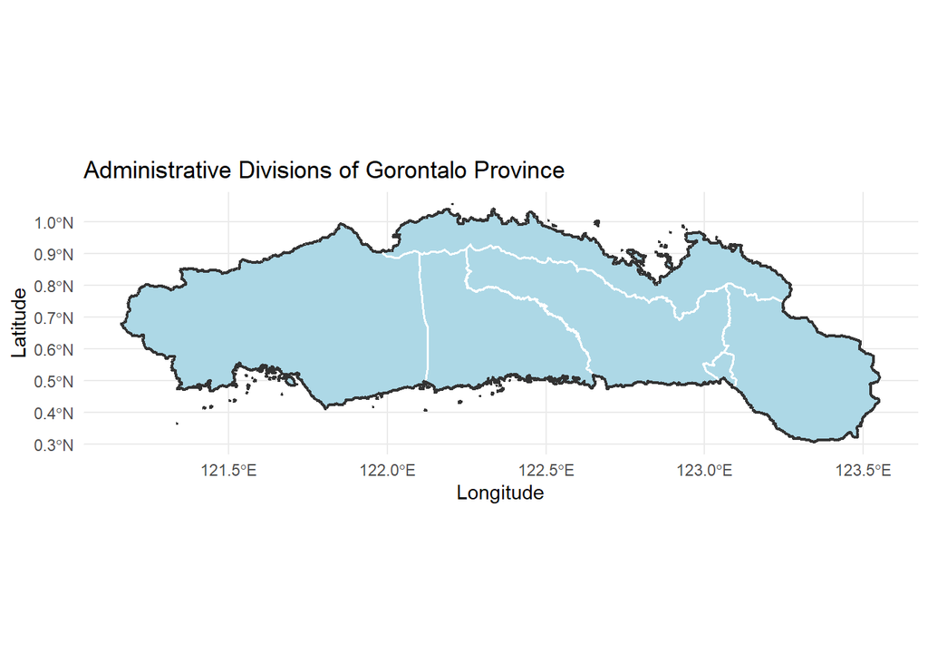

```r
# Let's preview the administrative boundaries!
ggplot() +
  geom_sf(
    data = gorontalo_regencies,
    fill = "lightblue",
    color = "white",
    linewidth = 0.6
  ) +
  geom_sf(
    data = gorontalo_province,
    fill = NA,
    color = "grey20",
    linewidth = 0.8
  ) +
  labs(
    title = "Administrative Divisions of Gorontalo Province",
    x = "Longitude",
    y = "Latitude"
  ) +
  theme_minimal()
```

**Understanding our code**

We use two `geom_sf()` layers:

1. The first layer draws the boundaries of Gorontalo’s regencies and city.
2. The second layer adds the provincial outline.

The `fill = NA` argument makes the provincial layer transparent, allowing the internal administrative boundaries to remain visible.

At this stage, all six administrative divisions share the same fill colour. We will assign different colours in a later step.

## 5.4 What have we learned?

In this step, we have learned how to:

1. Identify a province using its administrative code.
2. Filter spatial data using `dplyr`.
3. Extract administrative divisions from a larger dataset.
4. Verify the completeness of our extracted data.
5. Visualise administrative boundaries using multiple `geom_sf()` layers.

We now have a spatial object called `gorontalo_regencies`, containing the six administrative divisions of Gorontalo Province.

Next, let’s prepare English names for our administrative map!

# 6 Translating Administrative Division Names into English

Now that we have extracted Gorontalo’s five regencies and one city, let’s prepare their names for our English-language map!

Our spatial dataset uses Indonesian administrative names. For academic presentation, we will create a new variable containing their English equivalents while preserving the original names.

## 6.1 Let’s inspect the original administrative names!

Before translating the names, let’s examine how they are recorded in our dataset.

```r
# Let's inspect the original names!
gorontalo_regencies %>%
  st_drop_geometry() %>%
  select(nama_kabupaten, tipe) %>%
  print()
```

```
##              nama_kabupaten      tipe
## 1       Kabupaten Gorontalo KABUPATEN
## 2         Kabupaten Boalemo KABUPATEN
## 3    Kabupaten Bone Bolango KABUPATEN
## 4        Kabupaten Pohuwato KABUPATEN
## 5 Kabupaten Gorontalo Utara KABUPATEN
## 6            Kota Gorontalo      KOTA
```

**Understanding our code**

We use `st_drop_geometry()` to temporarily exclude geographic shapes from the displayed table.

The `select()` function allows us to focus on two variables:

- `nama_kabupaten`: The original administrative name.
- `tipe`: The administrative division type.

Some names may include prefixes such as *Kabupaten* or *Kota*. We need to account for these differences when creating our English labels.

## 6.2 Let’s translate the administrative names!

We will use `mutate()` and `case_when()` to create a new variable called `region_english`.

```r
# Let's create our English labels!
gorontalo_regencies <- gorontalo_regencies %>%
  mutate(
    region_english = case_when(
      grepl("Gorontalo Utara", nama_kabupaten) ~ "Gorontalo Utara Regency",
      grepl("Bone Bolango", nama_kabupaten) ~ "Bone Bolango Regency",
      grepl("Boalemo", nama_kabupaten) ~ "Boalemo Regency",
      grepl("Pohuwato", nama_kabupaten) ~ "Pohuwato Regency",
      grepl("Kota Gorontalo", nama_kabupaten) ~ "Gorontalo City",
      grepl("Gorontalo", nama_kabupaten) ~ "Gorontalo Regency",
      TRUE ~ NA_character_
    )
  )
```

**Understanding our code**

Let’s look at the three main functions:

| Function | What does it do? |
| --- | --- |
| `mutate()` | Creates or modifies variables |
| `case_when()` | Assigns values based on multiple conditions |
| `grepl()` | Checks whether a text pattern appears in a string |

For example:

```r
grepl("Bone Bolango", nama_kabupaten)
```

This checks whether the name contains `"Bone Bolango"`, even if it is written as `"Kabupaten Bone Bolango"`.

**Why does the order matter?**

The conditions in `case_when()` are evaluated from top to bottom.

For example, `"Gorontalo Utara"` must appear before the more general `"Gorontalo"` condition. Otherwise, North Gorontalo could be incorrectly labelled as Gorontalo Regency.

## 6.3 Let’s compare the Indonesian and English names!

Now, let’s compare the original names with their English equivalents.

```r
# Let's compare our administrative names!
gorontalo_names <- gorontalo_regencies %>%
  st_drop_geometry() %>%
  select(nama_kabupaten, tipe, region_english)

print(gorontalo_names)
```

```
##              nama_kabupaten      tipe          region_english
## 1       Kabupaten Gorontalo KABUPATEN       Gorontalo Regency
## 2         Kabupaten Boalemo KABUPATEN         Boalemo Regency
## 3    Kabupaten Bone Bolango KABUPATEN    Bone Bolango Regency
## 4        Kabupaten Pohuwato KABUPATEN        Pohuwato Regency
## 5 Kabupaten Gorontalo Utara KABUPATEN Gorontalo Utara Regency
## 6            Kota Gorontalo      KOTA          Gorontalo City
```

**What should we expect?**

Our dataset should now contain the following English labels:

| Indonesian administrative name | English label |
| --- | --- |
| Kabupaten Boalemo | Boalemo Regency |
| Kabupaten Bone Bolango | Bone Bolango Regency |
| Kabupaten Gorontalo | Gorontalo Regency |
| Kabupaten Gorontalo Utara | Gorontalo Utara Regency |
| Kabupaten Pohuwato | Pohuwato Regency |
| Kota Gorontalo | Gorontalo City |

We have retained *Gorontalo Utara* as a geographic name while translating its administrative designation into *Regency*.

## 6.4 Let’s verify our translations!

Before proceeding, let’s ensure that all six administrative divisions have valid English labels.

```r
# Let's check for missing translations!
sum(is.na(gorontalo_regencies$region_english))
```

```
## [1] 0
```

```r
# Let's check for unique English names!
length(unique(gorontalo_regencies$region_english))
```

```
## [1] 6
```

```r
# Let's validate our labels!
stopifnot(
  !anyNA(gorontalo_regencies$region_english),
  dplyr::n_distinct(gorontalo_regencies$region_english) == 6
)
```

**What should we expect?**

The first two commands should return:

```
[1] 0
[1] 6
```

This means:

- `0`: No administrative divisions are missing an English label.
- `6`: All six administrative divisions have distinct labels.

The `stopifnot()` function ensures that our data meet both conditions before we proceed.

## 6.5 What have we learned?

In this step, we have learned how to:

1. Inspect administrative names in a spatial dataset.
2. Create a new variable using `mutate()`.
3. Translate names using `case_when()` and `grepl()`.
4. Preserve original Indonesian names alongside English labels.
5. Validate the completeness and uniqueness of our translations.

Our spatial object, `gorontalo_regencies`, now contains the variable `region_english`, which we will use for map colours, labels, and legends.

Next, let’s visualise Gorontalo’s six administrative divisions using different colours!

# 7 Visualising Administrative Divisions of Gorontalo Province

Now that we have prepared the English administrative names, let’s start creating our map!

In this step, we will use `ggplot2` to visualise Gorontalo’s five regencies and one city. Each administrative division will be represented by a different colour, making it easier to distinguish their geographic boundaries.

## 7.1 Let’s create our first administrative map!

We will begin by combining our spatial data with `ggplot2`.

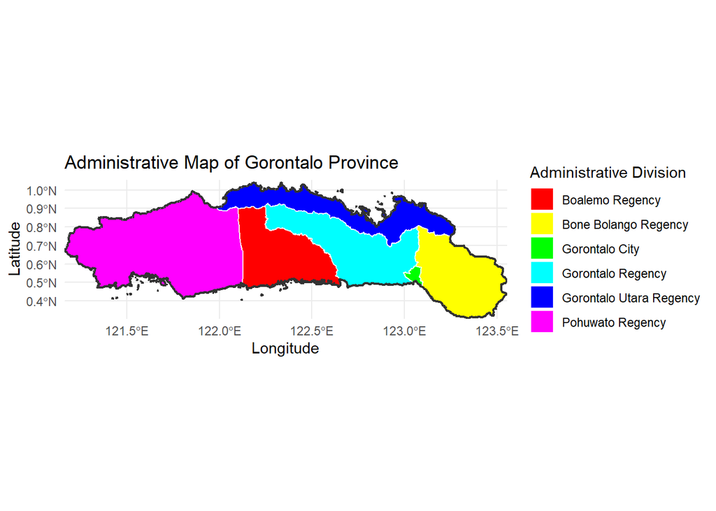

```r
# Let's create our administrative map!
gorontalo_map <- ggplot() +
  geom_sf(
    data = gorontalo_regencies,
    aes(fill = region_english),
    color = "white",
    linewidth = 0.5
  ) +
  geom_sf(
    data = gorontalo_province,
    fill = NA,
    color = "grey20",
    linewidth = 0.8
  ) +
  coord_sf(expand = FALSE) +
  scale_fill_manual(
    values = setNames(
      rainbow(6),
      sort(unique(gorontalo_regencies$region_english))
    )
  ) +
  labs(
    title = "Administrative Map of Gorontalo Province",
    fill = "Administrative Division",
    x = "Longitude",
    y = "Latitude"
  ) +
  theme_minimal()

# Let's see our map!
print(gorontalo_map)
```

**What should we expect?**

Our map should display six administrative divisions, each with a different colour.

The provincial boundary should appear as a darker outline, while the internal boundaries between regencies and the city should appear in white.

A legend on the right identifies the six administrative divisions using their English names.

### 7.1.1 Understanding our map layers

Let’s explore how `ggplot2` builds our map.

Unlike a single image, a `ggplot2` visualisation consists of multiple layers that can be added or modified independently.

| Function | Purpose |
| --- | --- |
| `ggplot()` | Initialises the map |
| `geom_sf()` | Draws geographic features |
| `aes(fill = region_english)` | Assigns colours based on administrative names |
| `coord_sf()` | Handles spatial coordinates |
| `scale_fill_manual()` | Defines the map’s colour palette |
| `labs()` | Adds titles and axis labels |
| `theme_minimal()` | Applies a clean visual theme |

The `+` operator connects these components into a single visualisation.

## 7.2 Let’s understand our geographic layers!

Our map contains two `geom_sf()` layers.

**First layer: Administrative divisions**

```r
geom_sf(
  data = gorontalo_regencies,
  aes(fill = region_english),
  color = "white",
  linewidth = 0.5
)
```

This layer draws the five regencies and one city.

The `fill` aesthetic assigns different colours based on `region_english`, while `color` and `linewidth` control the administrative boundaries.

**Second layer: Provincial boundary**

```r
geom_sf(
  data = gorontalo_province,
  fill = NA,
  color = "grey20",
  linewidth = 0.8
)
```

This layer draws the provincial outline.

Setting `fill = NA` makes the layer transparent, allowing the administrative divisions underneath to remain visible.

The provincial outline is slightly thicker than the internal boundaries to distinguish the two administrative levels.

## 7.3 Let’s explore our colour palette!

For our initial map, we use the `rainbow()` function to generate six different colours.

```r
# Let's generate six colours!
rainbow(6)
```

```
## [1] "#FF0000" "#FFFF00" "#00FF00" "#00FFFF" "#0000FF" "#FF00FF"
```

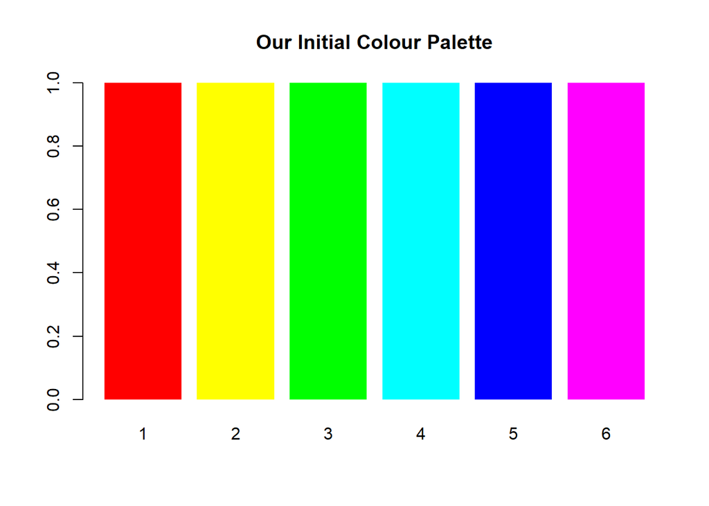

```r
# Let's preview our colour palette!
barplot(
  rep(1, 6),
  col = rainbow(6),
  border = NA,
  main = "Our Initial Colour Palette",
  names.arg = 1:6
)
```

**Understanding our code**

- `rainbow(6)` generates six colours.
- `rep(1, 6)` creates six bars of equal height.
- `barplot()` displays the colours.
- `col` controls the fill colours.
- `border = NA` removes the bar outlines.

In our map, `setNames()` associates these colours with the six administrative names.

We also use `sort()` to keep the names in a consistent order.

This is our starting palette. Later, we will replace it with more distinguishable colours for our final academic map.

## 7.4 Let’s understand our map coordinates!

Our map uses:

```r
coord_sf(expand = FALSE)
```

The `coord_sf()` function manages the geographic coordinate system used by `ggplot2`.

Setting `expand = FALSE` removes the default expansion around the plotting area, producing a tighter map layout.

We also use:

```r
labs(
  x = "Longitude",
  y = "Latitude"
)
```

These labels describe the geographic axes when the map is displayed using longitude and latitude coordinates.

## 7.5 What have we learned?

In this step, we have learned how to:

1. Create an administrative map using `ggplot2`.
2. Draw geographic boundaries using `geom_sf()`.
3. Assign different colours to administrative divisions.
4. Combine multiple spatial layers.
5. Customise map titles, axes, and legends.
6. Explore colour palettes using R.

We now have our first coloured administrative map of Gorontalo Province!

Our map already displays the six administrative divisions, but their names are only visible in the legend.

Next, let’s add the administrative names directly to the map!

# 8 Adding Administrative Labels to Our Map

Our map now displays Gorontalo’s five regencies and one city in different colours. However, readers still need to look at the legend to identify each administrative division.

Let’s make our map more informative by adding the administrative names directly to their geographic locations!

## 8.1 Let’s find suitable label positions!

Before adding labels, we need to determine where each administrative name should appear.

We will use `st_point_on_surface()` from the `sf` package to generate a point within each administrative division.

However, geographic coordinates are usually expressed in longitude and latitude. But wait……! do you know how to calculate label positions more appropriately? To execute this, we will first transform our spatial data into a projected coordinate reference system.

```r
# Let's calculate our label positions!
gorontalo_labels <- gorontalo_regencies %>%
  st_transform(32651) %>%
  st_point_on_surface() %>%
  st_transform(4326)
# Let's inspect our label points!
print(gorontalo_labels)
```

```
## Simple feature collection with 6 features and 14 fields
## Geometry type: POINT
## Dimension:     XY
## Bounding box:  xmin: 121.6471 ymin: 0.5352729 xmax: 123.3098 ymax: 0.8663965
## Geodetic CRS:  WGS 84
##     id kode_kab kode_prov            nama_kabupaten      tipe  area_km2
## 1 7501     7501        75       Kabupaten Gorontalo KABUPATEN 2160.2544
## 2 7502     7502        75         Kabupaten Boalemo KABUPATEN 1830.4658
## 3 7503     7503        75    Kabupaten Bone Bolango KABUPATEN 1888.9435
## 4 7504     7504        75        Kabupaten Pohuwato KABUPATEN 4370.9210
## 5 7505     7505        75 Kabupaten Gorontalo Utara KABUPATEN 1703.1821
## 6 7571     7571        75            Kota Gorontalo      KOTA   70.8291
##   jumlah_penduduk jumlah_kk          kepadatan luas_wilayah jumlah_kec
## 1          421699    137652 195.19812402000002     2160.364         19
## 2          152098     49183         83.0743938     1830.865          7
## 3          173416     55770        91.80316761     1888.998         18
## 4          161727     52906        37.00542679     4370.359         13
## 5          131338     41007  77.09312127000001     1703.628         11
## 6          203812     66203 2873.3029760500003       70.933          9
##   jumlah_desa jumlah_kel                   geometry          region_english
## 1         191         14  POINT (122.7235 0.700987)       Gorontalo Regency
## 2          82          0 POINT (122.3358 0.6875831)         Boalemo Regency
## 3         160          5 POINT (123.3098 0.5560122)    Bone Bolango Regency
## 4         101          3 POINT (121.6471 0.7021448)        Pohuwato Regency
## 5         123          0 POINT (123.0494 0.8663965) Gorontalo Utara Regency
## 6           0         50 POINT (123.0422 0.5352729)          Gorontalo City
```

**Understanding our code**

| Function | What does it do? |
| --- | --- |
| `st_transform(32651)` | Projects the data into UTM Zone 51N |
| `st_point_on_surface()` | Generates a point within each geographic feature |
| `st_transform(4326)` | Converts the coordinates back to WGS84 longitude and latitude |

**Why do we transform our coordinates?**

Longitude and latitude are angular measurements expressed in degrees, rather than linear distances.

Some spatial operations are better performed using a projected coordinate reference system, where coordinates are expressed in metres.

Note that, Gorontalo is located within UTM Zone 51N, represented by EPSG:32651.

By transforming our data before calculating label positions, we can avoid the warning associated with applying `st_point_on_surface()` directly to longitude/latitude coordinates.

## 8.2 Let’s visualise our label positions!

Before adding administrative names, let’s see where our label points are located.

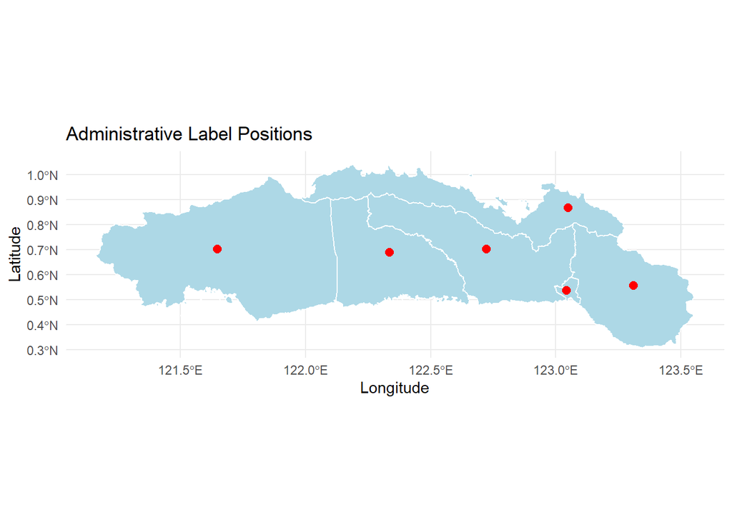

```r
# Let's preview our label positions!
ggplot() +
  geom_sf(
    data = gorontalo_regencies,
    fill = "lightblue",
    color = "white",
    linewidth = 0.5
  ) +
  geom_sf(
    data = gorontalo_labels,
    color = "red",
    size = 2.5
  ) +
  labs(
    title = "Administrative Label Positions",
    x = "Longitude",
    y = "Latitude"
  ) +
  theme_minimal()
```

**What should we expect?**

Our map should display six red points, each located within one of Gorontalo’s administrative divisions.

These points will serve as reference positions for our administrative labels.

**Understanding our code**

We have combined two spatial layers:

1. `gorontalo_regencies` displays the administrative boundaries.
2. `gorontalo_labels` displays the calculated label positions.

Notice that `geom_sf()` can visualise both polygon features and point features.

## 8.3 Let’s add our administrative names!

Now that we have calculated the label positions, let’s add the English administrative names directly to our coloured map.

We will use our friends… Who are they?? Yups they are `geom_sf_text()` from `ggplot2`. See below how they archive it!

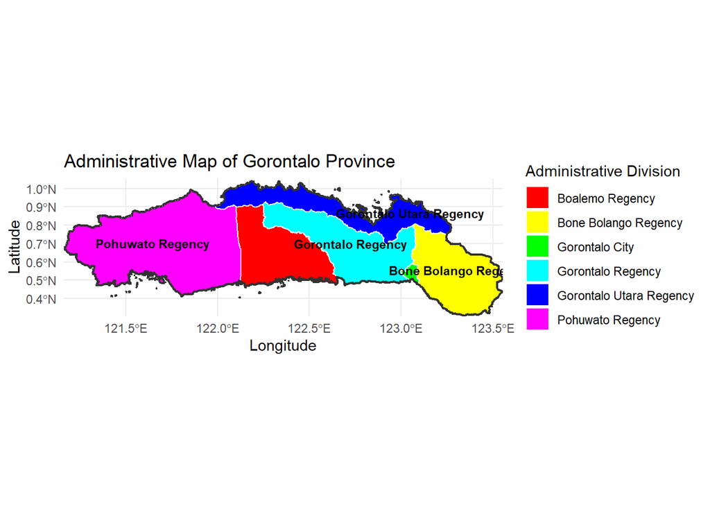

```r
# Let's add our administrative labels!
gorontalo_map_labelled <- gorontalo_map +
  geom_sf_text(
    data = gorontalo_labels,
    aes(label = region_english),
    size = 3,
    fontface = "bold",
    color = "black",
    check_overlap = TRUE
  )

# Let's see our labelled map!
print(gorontalo_map_labelled)
```

**Understanding our code**

| Argument | Purpose |
| --- | --- |
| `geom_sf_text()` | Adds text labels using spatial coordinates |
| `aes(label = region_english)` | Uses our English administrative names |
| `size = 3` | Controls the text size |
| `fontface = "bold"` | Displays labels in bold |
| `color = "black"` | Sets the label colour |
| `check_overlap = TRUE` | Suppresses some overlapping labels |

**What should we expect?**

Our map should now display administrative names directly over the geographic regions.

However, some labels may overlap or disappear, particularly in smaller administrative areas such as Gorontalo City.

This happens because geographic regions vary considerably in size and shape.

## 8.4 Let’s understand the limitations of our labels!

Although `geom_sf_text()` is useful for adding geographic labels, it has some limitations.

For example:

- Long administrative names may extend beyond their geographic boundaries.
- Labels may overlap in densely packed regions.
- Smaller administrative divisions may not have enough space for their names.
- `check_overlap = TRUE` may suppress labels rather than reposition them.

These issues do not necessarily indicate errors in our geographic data. Instead, they reflect the challenges of placing text within irregular geographic shapes.

To improve our map, we will later use `ggrepel` Doing so will help us reposition labels and draw connecting lines to their geographic locations.

## 8.5 What have we learned?

In this step, we have learned how to:

1. Calculate label positions using `st_point_on_surface()`.
2. Transform spatial coordinates between reference systems.
3. Visualise geographic points using `geom_sf()`.
4. Add administrative names using `geom_sf_text()`.
5. Identify limitations in automatic geographic labelling.

Our map now contains both administrative boundaries and geographic labels!

Next, let’s improve our English-labelled map using `ggrepel` to make the administrative names easier to read.

# 9 Improving Label Placement with `ggrepel`

Our map now displays the English names of Gorontalo’s administrative divisions. However, some labels may overlap or extend beyond their geographic boundaries.

Let’s improve their placement using the `ggrepel` package!

Unlike `geom_sf_text()`, which places labels at specified geographic coordinates, `ggrepel` can move labels away from one another to reduce overlaps.

## 9.1 Let’s extract the label coordinates!

In Step 7, we created `gorontalo_labels`, an `sf` object containing one point for each administrative division.

To use these points with `ggrepel`, we need to extract their longitude and latitude coordinates.

```r
# Let's extract our label coordinates!
label_coordinates <- st_coordinates(gorontalo_labels)

# Let's add longitude and latitude!
gorontalo_labels <- gorontalo_labels %>%
  mutate(
    longitude = label_coordinates[, 1],
    latitude = label_coordinates[, 2]
  )

# Let's inspect our label coordinates!
gorontalo_labels %>%
  st_drop_geometry() %>%
  select(region_english, longitude, latitude)
```

|  | region_english | longitude | latitude |
| --- | --- | --- | --- |
| 1 | Gorontalo Regency | 122.7235 | 0.7009870 |
| 2 | Boalemo Regency | 122.3358 | 0.6875831 |
| 3 | Bone Bolango Regency | 123.3098 | 0.5560122 |
| 4 | Pohuwato Regency | 121.6471 | 0.7021448 |
| 5 | Gorontalo Utara Regency | 123.0494 | 0.8663965 |
| 6 | Gorontalo City | 123.0422 | 0.5352729 |

**Understanding our code**

| Function or expression | Purpose |
| --- | --- |
| `st_coordinates()` | Extracts numeric coordinates from spatial points |
| `label_coordinates[, 1]` | Extracts the first coordinate (longitude) |
| `label_coordinates[, 2]` | Extracts the second coordinate (latitude) |
| `mutate()` | Adds the coordinates as new variables |
| `st_drop_geometry()` | Displays the attribute data without the geometry column |

**Why do we need numeric coordinates?**

In Step 7, `geom_sf_text()` could use the geometry column directly.

However, `geom_text_repel()` requires explicit `x` and `y` coordinates.

By creating `longitude` and `latitude`, we can use our geographic label positions with `ggrepel`.

## 9.2 Let’s add repelled labels to our map!

Now, let’s use `geom_text_repel()` to create a map with more flexible label placement.

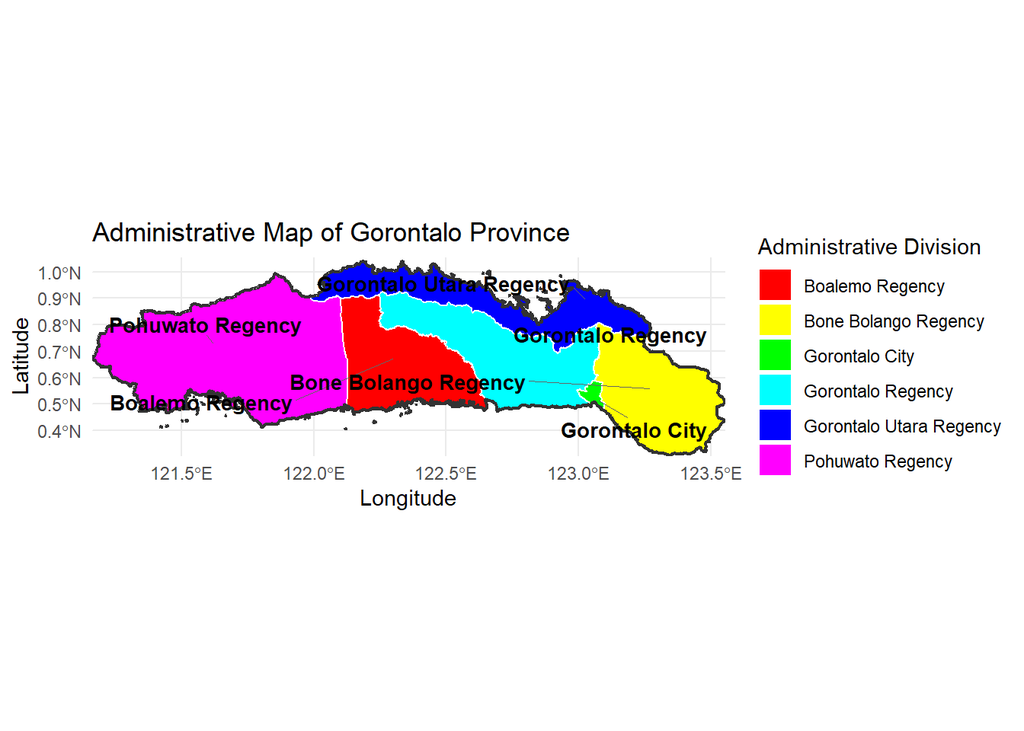

```r
# Let's improve our administrative labels!
gorontalo_map_repelled <- gorontalo_map +
  ggrepel::geom_text_repel(
    data = gorontalo_labels,
    aes(
      x = longitude,
      y = latitude,
      label = region_english
    ),
    size = 3.5,
    fontface = "bold",
    box.padding = 0.6,
    point.padding = 0.3,
    force = 3,
    max.overlaps = Inf,
    max.iter = 20000,
    min.segment.length = 0,
    segment.color = "grey40",
    segment.size = 0.3,
    seed = 123
  )

# Let's see our improved map!
print(gorontalo_map_repelled)
```

**What should we expect?**

Our map should display all six administrative names, with some labels moved away from their original geographic positions to reduce overlaps.

Thin connecting lines may appear between displaced labels and their corresponding geographic locations.

The exact positions may differ depending on the plot dimensions and available space.

## 9.3 8.3. Let’s Understand the `ggrepel` Arguments!

The `geom_text_repel()` function provides several options for controlling label placement.

| Argument | Purpose |
| --- | --- |
| `x`, `y` | Specify the original geographic label positions |
| `label` | Specifies the text to display |
| `box.padding` | Controls spacing around each label |
| `point.padding` | Controls spacing around the original anchor point |
| `force` | Controls the strength of label repulsion |
| `max.overlaps = Inf` | Prevents labels from being excluded by the overlap threshold |
| `max.iter` | Sets the maximum number of iterations used to find suitable positions |
| `min.segment.length = 0` | Allows connecting segments even when they are short |
| `segment.color` | Controls the colour of connecting lines |
| `segment.size` | Controls the thickness of connecting lines |
| `seed` | Helps make label placement reproducible |

**Why do we use `seed = 123`?**

The label placement algorithm can involve random initialisation.

Setting a seed helps us obtain consistent results when regenerating the map under the same conditions.

This is particularly useful when preparing figures for academic reports or publications.

## 9.4 Let’s compare our labelling methods!

We have now used two approaches to add administrative names to our map.

| Feature | `geom_sf_text()` | `geom_text_repel()` |
| --- | --- | --- |
| Uses `sf` geometry directly | Yes | No |
| Requires separate `x` and `y` coordinates | No | Yes |
| Automatically repositions labels | No | Yes |
| Can draw connecting lines | No | Yes |
| Useful for crowded maps | Limited | Generally better |

Both approaches are useful, but they serve different purposes.

`geom_sf_text()` is convenient when labels fit comfortably within their geographic regions.

`geom_text_repel()` is particularly helpful when administrative divisions are small, irregularly shaped, or located close together.

## 9.5 Let’s reflect on our map design!

Although `ggrepel` improves label placement, it does not guarantee that every label will remain within its administrative boundary.

This is because its main objective is to reduce overlaps between labels and other specified elements, rather than constrain text to geographic polygons.

For a map such as Gorontalo, this can be useful. Why……? Simply, it’s because long names, like “Gorontalo Utara Regency” and “Bone Bolango Regency”, may be easier to read when positioned outside their original anchor points.

However, we should still visually inspect our map before exporting it.

## 9.6 What have we learned?

In this step, we have learned how to:

1. Extract numeric coordinates from spatial point features.
2. Add longitude and latitude variables to an `sf` object.
3. Use `geom_text_repel()` to reduce overlapping labels.
4. Customise label spacing and connecting lines.
5. Improve the reproducibility of label placement.
6. Evaluate the readability of an administrative map.

We now have an improved map called `gorontalo_map_repelled`. It contain all six administrative divisions with more flexible label placement.

Next, let’s refine our map’s colours, geographic extent, and overall appearance to create a publication-ready figure!

# 10 Refining Our Map for Academic Presentation

Our administrative map is almost complete!

We have successfully visualised Gorontalo’s five regencies and one city We have translated their names into English, and improved label placement using `ggrepel`.

Now, let’s refine the colours, geographic extent, and visual appearance of our map.

Our goal is to create a clear and professional map suitable for academic presentation.

## 10.1 Let’s create a custom colour palette!

In Step 6, we used `rainbow()` to assign six colours automatically.

Although this was useful for learning how colour scales work, we can improve our map by selecting colours individually.

Let’s create a named colour palette for Gorontalo’s administrative divisions!

```r
# Let's define our custom colours!
region_colours <- c(
  "Boalemo Regency" = "#D55E00",
  "Bone Bolango Regency" = "#E6AB02",
  "Gorontalo City" = "#CC79A7",
  "Gorontalo Regency" = "#009E73",
  "Gorontalo Utara Regency" = "#0072B2",
  "Pohuwato Regency" = "#88BDE6"
)

# Let's inspect our colours!
print(region_colours)
```

```
##         Boalemo Regency    Bone Bolango Regency          Gorontalo City
##               "#D55E00"               "#E6AB02"               "#CC79A7"
##       Gorontalo Regency Gorontalo Utara Regency        Pohuwato Regency
##               "#009E73"               "#0072B2"               "#88BDE6"
```

**Understanding our code**

We use `c()` to create a named vector containing six hexadecimal colour codes.

Each colour is associated with a specific administrative division.

| Administrative division | Colour code |
| --- | --- |
| Boalemo Regency | `#D55E00` |
| Bone Bolango Regency | `#E6AB02` |
| Gorontalo City | `#CC79A7` |
| Gorontalo Regency | `#009E73` |
| Gorontalo Utara Regency | `#0072B2` |
| Pohuwato Regency | `#88BDE6` |

Using a named vector is particularly useful because `ggplot2` can match colours to administrative names rather than relying on their order in the dataset.

## 10.2 Let’s preview our colour palette!

Before applying the colours to our map, let’s visualise them.

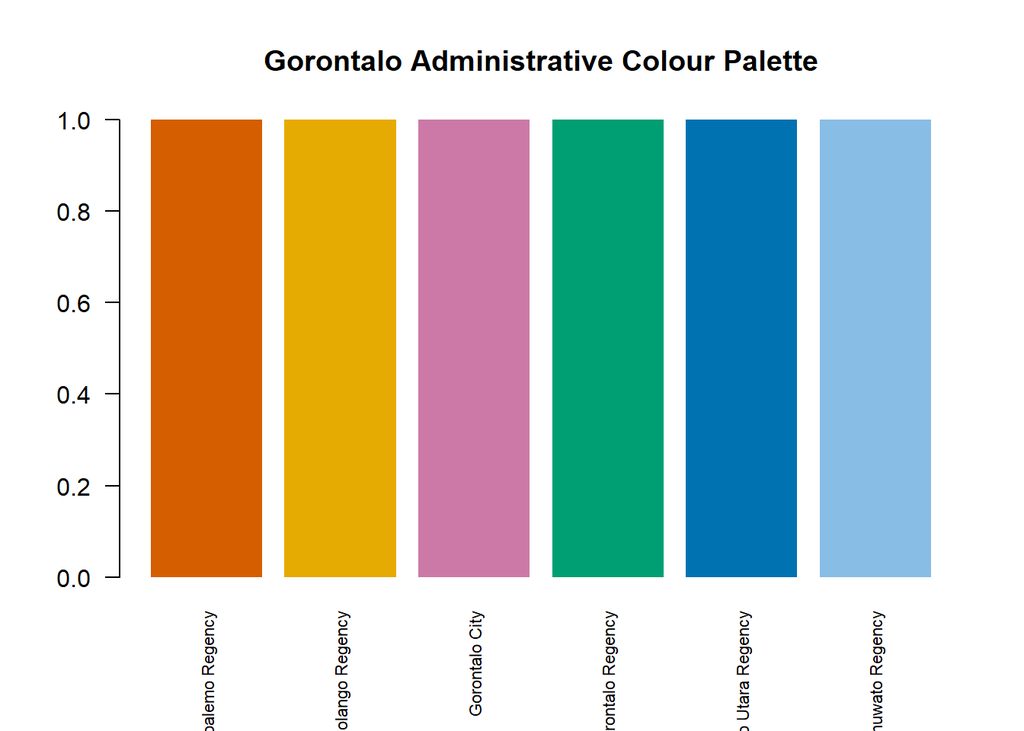

```r
# Let's preview our custom colour palette!
barplot(
  rep(1, length(region_colours)),
  col = region_colours,
  border = NA,
  names.arg = names(region_colours),
  las = 2,
  cex.names = 0.7,
  main = "Gorontalo Administrative Colour Palette"
)
```

**What should we expect?**

The plot should display six coloured bars representing our administrative divisions.

Each bar has the same height because we are visualising categorical colours rather than numerical values.

**Understanding our code**

- `length(region_colours)` counts the colours.
- `rep()` creates equal-height bars.
- `col` applies our custom colours.
- `names.arg` adds administrative names.
- `las = 2` rotates the labels vertically.
- `cex.names` adjusts their text size.

This simple preview helps us examine the palette before applying it to our geographic map.

## 10.3 Let’s create our refined administrative map!

Now, let’s combine everything we have learned into one map.

We will use our custom colours, improved labels, and a more focused geographic extent.

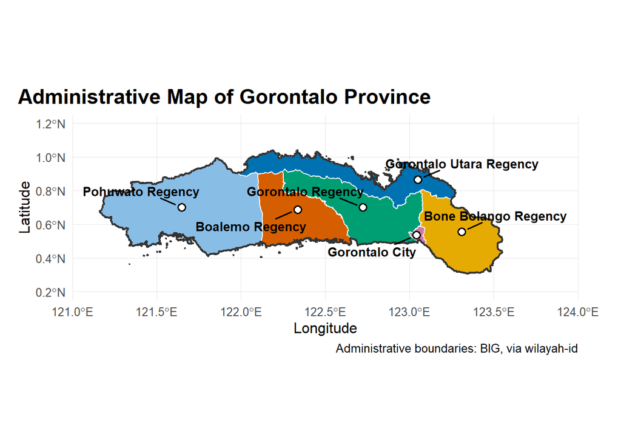

```r
# Let's create our refined administrative map!
gorontalo_map_final <- ggplot() +
  geom_sf(
    data = gorontalo_regencies,
    aes(fill = region_english),
    color = "white",
    linewidth = 0.5
  ) +
  geom_sf(
    data = gorontalo_province,
    fill = NA,
    color = "grey20",
    linewidth = 0.8
  ) +
  geom_sf(
    data = gorontalo_labels,
    shape = 21,
    fill = "white",
    color = "black",
    size = 2.5,
    stroke = 0.8
  ) +
  ggrepel::geom_text_repel(
    data = gorontalo_labels,
    aes(
      x = longitude,
      y = latitude,
      label = region_english
    ),
    size = 3.5,
    fontface = "bold",
    box.padding = 0.6,
    point.padding = 0.3,
    force = 3,
    max.overlaps = Inf,
    max.iter = 20000,
    min.segment.length = 0,
    segment.color = "black",
    segment.size = 0.6,
    seed = 123
  ) +
  scale_fill_manual(
    values = region_colours
  ) +
  coord_sf(
    xlim = c(121, 124),
    ylim = c(0.15, 1.25),
    expand = FALSE,
    clip = "off"
  ) +
  labs(
    title = "Administrative Map of Gorontalo Province",
    fill = "Administrative Division",
    x = "Longitude",
    y = "Latitude",
    caption = "Administrative boundaries: BIG, via wilayah-id"
  ) +
  theme_minimal(base_size = 12) +
  theme(
    plot.title = element_text(
      face = "bold",
      size = 17
    ),
    plot.title.position = "plot",
    legend.position = "none",
    panel.grid.major = element_line(
      color = "grey90",
      linewidth = 0.3
    ),
    plot.margin = margin(15, 35, 15, 15)
  )

# Let's see our final map!
print(gorontalo_map_final)
```

**What should we expect?**

Our refined map should display:

1. Six administrative divisions with distinct colours.
2. A dark provincial outline and white internal boundaries.
3. English administrative names positioned using `ggrepel`.
4. Longitude and latitude axes.
5. A clear title and a data-source caption.
6. No separate legend, since the names already appear directly on the map.

## 10.4 Let’s understand our geographic extent!

In our refined map, we use:

```r
coord_sf(
  xlim = c(121, 124),
  ylim = c(0.15, 1.25),
  expand = FALSE,
  clip = "off"
)
```

The `coord_sf()` function controls how our geographic data are displayed.

| Argument | Purpose |
| --- | --- |
| `xlim` | Specifies the longitude limits |
| `ylim` | Specifies the latitude limits |
| `expand = FALSE` | Removes automatic padding around the map |
| `clip = "off"` | Allows graphical elements to extend beyond the plotting panel |

**Why do we specify coordinate limits?**

By defining the geographic extent, we can focus the map on Gorontalo Province rather than displaying unnecessary surrounding space.

The `clip = "off"` argument is also useful when some administrative labels extend beyond the plotting panel.

However, we should still inspect the exported figure to ensure that labels are not cut off at the edges of the image.

## 10.5 Let’s understand our map theme!

We use `theme_minimal()` as the foundation of our map design.

Then, we customise several elements using `theme()`.

**Map title**

```r
plot.title = element_text(
  face = "bold",
  size = 17
)
```

This makes our title more prominent.

**Legend**

```r
legend.position = "none"
```

This removes the legend.

Since the administrative names already appear directly on the map, removing the legend helps reduce visual redundancy.

**Grid lines**

```r
panel.grid.major = element_line(
  color = "grey90",
  linewidth = 0.3
)
```

This creates subtle geographic grid lines without drawing too much attention away from the administrative boundaries.

**Plot margins**

```r
plot.margin = margin(15, 35, 15, 15)
```

This adjusts the space around the figure, providing additional room for titles and labels.

## 10.6 Let’s check our final map!

Before exporting our map, let’s confirm that our colour palette includes all six administrative divisions.

```r
# Let's verify our administrative colours!
setequal(
  unique(gorontalo_regencies$region_english),
  names(region_colours)
)
```

```
## [1] TRUE
```

```r
# Let's confirm that our final map exists!
class(gorontalo_map_final)
```

```
## [1] "ggplot2::ggplot" "ggplot"          "ggplot2::gg"     "S7_object"
## [5] "gg"
```

**What should we expect?**

The first command should return:

```
[1] TRUE
```

This confirms that the administrative names in our spatial dataset match the names in our colour palette.

The second command should identify our map as a `ggplot` object.

## 10.7 What have we learned?

In this step, we have learned how to:

1. Create a custom colour palette using hexadecimal colour codes.
2. Assign colours consistently using a named vector.
3. Refine geographic boundaries and administrative labels.
4. Adjust the geographic extent using `coord_sf()`.
5. Customise map titles, grid lines, margins, and legends.
6. Validate the relationship between administrative names and map colours.

We now have our refined administrative map, stored as `gorontalo_map_final`.

Next, let’s export our map as high-resolution PNG and PDF files for academic use!

# 11 Exporting Our Map as High-Resolution PNG and PDF

Congratulations! We have successfully created our administrative map of Gorontalo Province.

Our final map includes six administrative divisions, English labels, custom colours, and a refined layout.

Now, let’s save our map so we can use it outside RStudio.

## 11.1 Let’s export our map as a PNG file!

First, we will save our map as a high-resolution PNG image using `ggsave()`.

```r
# Let's export our map as a high-resolution PNG!
ggsave(
  filename = "Map_of_Gorontalo.png",
  plot = gorontalo_map_final,
  width = 12,
  height = 5,
  units = "in",
  dpi = 600,
  bg = "white"
)
```

**Understanding our code**

The `ggsave()` function allows us to save a `ggplot2` visualisation as an external file.

| Argument | Purpose |
| --- | --- |
| `filename` | Specifies the output file name and format |
| `plot` | Identifies the plot to export |
| `width` | Sets the figure width |
| `height` | Sets the figure height |
| `units` | Specifies the measurement units |
| `dpi` | Sets the raster image resolution |
| `bg` | Sets the background colour |

**Why do we use 600 dpi?**

DPI stands for *dots per inch*. For raster images, the resolution setting determines how many pixels are generated per inch.

A higher resolution generally produces sharper text, boundaries, and other visual details when the image is displayed or printed at its intended size.

Our PNG file uses:

- Width: 12 inches
- Height: 5 inches
- Resolution: 600 dpi

This produces an image measuring approximately **7200 × 3000 pixels**.

Such a resolution is useful when preparing figures for academic publications, although individual journals may specify different requirements.

## 11.2 Let’s export our map as a PDF file!

Next, let’s save our map as a PDF.

```r
# Let's export our map as a PDF!
ggsave(
  filename = "Map_of_Gorontalo.pdf",
  plot = gorontalo_map_final,
  width = 14,
  height = 7,
  units = "in",
  bg = "white"
)
```

**Why do we also need a PDF?**

Unlike PNG images, PDF files can preserve vector graphics.

Vector graphics represent lines and shapes mathematically rather than as a fixed grid of pixels.

This means that geographic boundaries and text can generally be enlarged without losing sharpness.

PDF is therefore particularly useful for:

- Academic publications
- Thesis figures
- Posters
- High-quality printing

Notice that we do not specify `dpi` for this PDF export. The resolution setting is primarily relevant to raster graphics, while vector elements remain scalable.

## 11.3 Let’s compare PNG and PDF formats!

Both formats are useful, but they serve different purposes.

| Feature | PNG | PDF |
| --- | --- | --- |
| Graphic type | Raster | Supports vector graphics |
| Resolution | Pixel-based | Vector elements are scalable |
| Easy to insert into slides | Yes | Depends on software |
| Suitable for academic publications | Yes | Yes |
| Best for | Images and presentations | Printing and scalable figures |

**Which format should we use?**

PNG is convenient when inserting a map into presentation slides, documents, or online materials.

PDF is useful when preserving scalable lines, text, and geographic boundaries.

For academic work, it is often helpful to keep both formats available.

## 11.4 Let’s check whether our files were saved!

After exporting our map, let’s verify that both files exist.

```r
# Let's check our exported files!
file.exists("Map_of_Gorontalo.png")
```

```
## [1] TRUE
```

```r
file.exists("Map_of_Gorontalo.pdf")
```

```
## [1] TRUE
```

```r
# Let's locate our working directory!
getwd()
```

```
## [1] "D:/ANU - MGAL (Adv) - Irvan/4th semester - Postgrad Thesis MGALAdv/Indonesian Map"
```

**What should we expect?**

If both exports were successful, the first two commands should return:

```
[1] TRUE
[1] TRUE
```

The `getwd()` function displays the current working directory.

By default, our exported files are saved relative to this directory because we have not specified another folder.

**Note:** When knitting an R Markdown document, the working directory may differ from the directory used during an interactive RStudio session. We should check the output location if our files do not appear where expected.

## 11.5 Let’s inspect our exported files!

We can also inspect the file sizes to confirm that our outputs were created.

```r
# Let's inspect our exported files!
file.info(
  c(
    "Map_of_Gorontalo.png",
    "Map_of_Gorontalo.pdf"
  )
)[, c("size", "mtime")]
```

|  | size | mtime |
| --- | --- | --- |
| Map_of_Gorontalo.png | 665106 | 2026-10-25 01:21:12.645946 |
| Map_of_Gorontalo.pdf | 82411 | 2026-10-25 01:21:13.359601 |

**Understanding our code**

- `file.info()` retrieves information about the exported files.
- `size` reports file size in bytes.
- `mtime` reports the most recent modification time.

This is useful when checking whether our files were generated or updated during the latest execution.

## 11.6 What have we learned?

In this step, we have learned how to:

1. Export a `ggplot2` map using `ggsave()`.
2. Save high-resolution PNG images.
3. Export scalable PDF graphics.
4. Understand the differences between raster and vector formats.
5. Check whether exported files exist.
6. Inspect file information and output locations.

We have now successfully created and exported our administrative map of Gorontalo Province!

# 12 Wrapping Up

Congratulations! We have reached the end of our journey in mapping Gorontalo Province using R!

What started with retrieving geographic data has now become a complete administrative map showing Gorontalo’s five regencies and one city.

Along the way, we have explored how spatial data work, learned to manipulate geographic features, and discovered how different R packages can help us transform geographic information into meaningful visualisations.

But before we finish, let’s reflect on what we have accomplished!

## 12.1 What have we accomplished?

Throughout this tutorial, we have completed ten important steps:

1. **Preparing our R environment:** We loaded the packages required for spatial data processing and visualisation.
2. **Retrieving provincial boundaries:** We obtained Indonesia’s provincial geographic data and extracted Gorontalo Province.
3. **Retrieving administrative divisions:** We accessed geographic boundaries at the regency and city levels.
4. **Extracting Gorontalo’s administrative divisions:** We identified its five regencies and one city using administrative codes.
5. **Translating administrative names:** We created English labels while preserving the original Indonesian names.
6. **Creating our first administrative map:** We visualised geographic boundaries using `ggplot2`.
7. **Adding geographic labels:** We calculated label positions using spatial operations and coordinate transformations.
8. **Improving label placement:** We used `ggrepel` to make administrative names easier to read.
9. **Refining our map:** We customised colours, geographic extent, and visual appearance.
10. **Exporting our final map:** We saved our map as high-resolution PNG and PDF files.

More importantly, we have learned how several R packages work together:

| Package | What Have We Learned? |
| --- | --- |
| `sf` | How to retrieve, manage, transform, and visualise spatial data |
| `dplyr` | How to filter, select, and manipulate geographic attributes |
| `ggplot2` | How to construct and customise geographic visualisations |
| `ggrepel` | How to improve the readability of geographic labels |

By combining these tools, we have developed a reproducible workflow for creating administrative maps.

## 12.2 Let’s look at our final outputs!

We have produced two versions of our administrative map:

- **`Map_of_Gorontalo.png`** — A high-resolution image suitable for presentations, reports, and other visual materials.
- **`Map_of_Gorontalo.pdf`** — A scalable graphic suitable for academic publications and high-quality printing.

Both files represent the same geographic information, but they offer different advantages depending on how we intend to use our map.

Our final map illustrates the six administrative divisions of Gorontalo Province using distinct colours and English labels.

And that’s our final product!

## 12.3 Where to from Here?

So, have we finished learning about geographic mapping in R?

Not quite! In fact, we have only scratched the surface.

Now that we understand the basic workflow, there are many exciting directions we can explore.

**What if we wanted to map another Indonesian province?**

We could adapt our existing code by changing the province selected during data filtering.

**What if we wanted to explore population distribution?**

We could use demographic attributes to create a choropleth map, where colours represent numerical values such as population size or density.

**What if we wanted to map languages and their geographic distribution?**

We could combine administrative boundaries with linguistic data to visualise where particular languages or language varieties are spoken.

This could be especially useful for research in sociolinguistics, language documentation, and language maintenance.

**And what if we wanted to make our map interactive?**

We could explore additional R packages, such as `leaflet`, to create interactive maps that allow users to zoom, navigate, and explore geographic information.

The possibilities extend far beyond the administrative map we have created here!

## 12.4 A final thought

Creating a map is not simply about drawing geographic boundaries.

It is also about understanding how geographic information is organised, represented, analysed, and communicated.

Throughout this tutorial, we have seen how a few lines of R code can gradually develop into a detailed geographic visualisation.

We have also learned that effective mapping involves more than writing code. It requires careful data selection, coordinate management, thoughtful design, and attention to readability.

Most importantly, we now have a foundation that we can build upon for future spatial research.

# 13 Acknowledgements

I would like to acknowledge the developers and contributors of R and its open-source ecosystem, particularly the `sf`, `dplyr`, `ggplot2`, and `ggrepel` packages, whose tools made the spatial data processing and visualisation presented in this tutorial possible.

I also acknowledge Dhany Yudi Prasetyo, the developer of the wilayah-id API, for making Indonesian administrative geographic information accessible through a publicly available geospatial service (Prasetyo, 2026).

My appreciation also extends to Badan Informasi Geospasial (BIG) for providing the underlying administrative boundary geometries and the Ministry of Home Affairs of the Republic of Indonesia (Kemendagri) for the administrative codes and regional names incorporated into the dataset.

This tutorial was developed as an independent learning project to explore reproducible spatial visualisation using R, with particular attention to Gorontalo Province, Indonesia.

# 14 References

Pebesma, E. (2018). Simple features for r: Standardized support for spatial vector data. *The R Journal*, *10*(1), 439–446. https://doi.org/10.32614/RJ-2018-009

Pebesma, E., & Bivand, R. (2023). *Spatial data science: With applications in r*. Chapman; Hall/CRC. https://doi.org/10.1201/9780429459016

Prasetyo, D. Y. (2026). *Wilayah-id: API dan webmap batas administrasi indonesia*. GitHub repository. https://github.com/dhanyyudi/wilayah-id

R Core Team. (2026). *R: A language and environment for statistical computing*. R Foundation for Statistical Computing. https://www.R-project.org/

Slowikowski, K. (2026). *Ggrepel: Automatically position non-overlapping text labels with ggplot2*. https://doi.org/10.32614/CRAN.package.ggrepel

Wickham, H. (2016). *ggplot2: Elegant graphics for data analysis*. Springer. https://doi.org/10.1007/978-3-319-24277-4

Wickham, H., François, R., Henry, L., Müller, K., & Vaughan, D. (2026). *Dplyr: A grammar of data manipulation*. https://doi.org/10.32614/CRAN.package.dplyr

**Congratulations on completing our Gorontalo mapping tutorial!**

**Happy mapping, and see you in our next R adventure!**

*Odu’olo*

**Irvan N**

Belconnen, Australian Capital Territory.